# Introduction to SPSS

Checking, describing and testing survey data in SPSS through the Virtual Computing Lab

Author

NC State University Libraries — Data Science Services

Published

October 27, 2026

Open this guide anywhere, including in the VCL: go.ncsu.edu/dss-intro-spss

**ImportantHow to use this guide**

This is the page we work from in the session. Every step is written out, so you can follow along, catch up if you fall behind, and come back to it later.

- **Steps are in blue boxes** titled with where you do them: *In your browser*, *In the VCL* or *In SPSS*. Everything outside a box explains what the steps do and how to read the results.
- **The codebook is in Section 2.** Links marked **↑** or **↓** jump to a variable’s row in it, and each row links on to the places we use that variable.
- **Have your phone ready.** You’ll confirm your NC State login with Duo more than once.

# Welcome

## What you’ll be able to do

- Recognize when to use the Virtual Computing Lab (VCL).
- Justify good data storage strategies.
- Inspect the details about variables within a dataset to ensure good quality analysis.
- Explore SPSS software for statistical data analysis.

## Agenda

1. Access SPSS through the VCL (Section 1).
2. Download the dataset within the VCL, and read its codebook (Section 2). Normally you would download outside the VCL, but we shortcut a step here for time’s sake.
3. Open SPSS and review its interface.
4. Examine the dataset: variable types, measurement levels, missing values and value labels (Section 3).
5. Run descriptive statistics and make graphs: a bar chart, a histogram and a crosstab (Section 4).
6. Run inferential tests: a correlation, a one-way ANOVA and a simple linear regression (Section 5). T-tests and normality checks are in the Appendix.
7. Export results (Section 6).
8. Store exports in cloud storage and exit the VCL. We may not practice this in class.

# 1 Student access to SPSS

SPSS is [not available for personal computer download](https://www.lib.ncsu.edu/software/spss) for students. The best ways to access it are:

1. **Using the [Virtual Computing Lab](https://vcl.ncsu.edu/scheduling) (VCL).**
2. Locally, at Hill Library’s Data Experience Lab or Hunt Library’s Dataspace computers. To reserve one, select **Data Workstation** at rooms.lib.ncsu.edu.
3. At a [Unity Computer Lab](https://ncsu.service-now.com/sp?id=kb_article_view&sysparm_article=KB0022523).

We focus today on setting up and using the VCL for SPSS.

## 1.1 SPSS access via the VCL

**NoteIn your browser: reserve SPSS in the VCL**

1. Go to [vcl.ncsu.edu/scheduling](https://vcl.ncsu.edu/scheduling/).
2. Select the **NCSU Login** authentication method and click **Proceed to Login**. Log in with your Unity ID (you will need to Duo authenticate).
3. Click the **Reservations** tab in the header, then the **New Reservation** button.
4. Select **SPSS/AMOS (AVD)** from the dropdown.
5. Click **Connect**.
6. Click **Open the AVD Portal**.
7. Pick an account (select your NC State email address) and enter your password. Duo authenticate again if asked.
8. Click **Yes** to stay signed in.

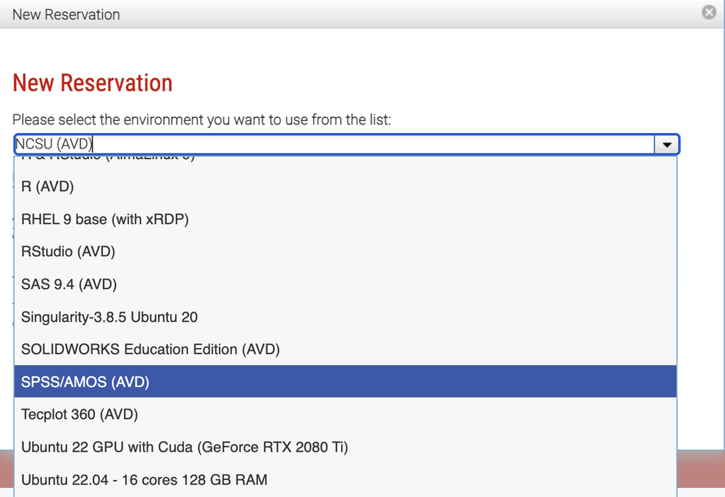

The New Reservation dialog, with SPSS/AMOS (AVD) chosen from the list of environments.

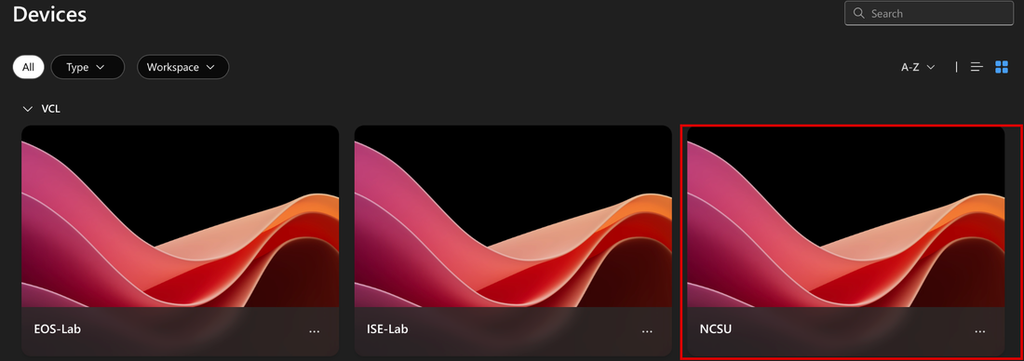

The AVD portal lists the VCL devices. Choose the one named NCSU.

**NoteIn the VCL: open the NCSU desktop and start SPSS**

1. Click the **NCSU** computer icon.
2. Select **Connect**.
3. Enter your Unity ID and password to sign in.
4. Click **OK** to acknowledge the folder where you’ll save your work.
5. Now you’re in the VCL! Wait for it to load.
6. Open **IBM SPSS Statistics** from the desktop. You may notice a little lag between clicks at first. While the software is opening, move on to the next section.

[figure not shown]

The VCL desktop. The IBM SPSS Statistics icon is in the second column.

## 1.2 Download the sample data

We will be using a sample file from ABC Insurance’s employee survey: one row per employee, with their demographics, job role, tenure, salary, performance evaluation and survey answers. It’s a teaching dataset from SAGE Research Methods, modified for this session. Its **codebook** (or data dictionary), which tells you what each variable means and how its values are coded, is in this guide, in Section 2. You only need to download the data file.

**NoteIn the VCL: download the data file**

1. In the VCL, open a web browser and go to this guide: go.ncsu.edu/dss-intro-spss.
2. Click this link to download the data file: TeachingData.sav.
3. Open **File Explorer** and make sure you can find where **TeachingData.sav** was downloaded. Most likely it’s in the Downloads folder of your VCL login: **This PC > C: > Users > [your Unity ID] > Downloads**.

**WarningGotcha: the VCL doesn’t keep your files**

Your data can’t be reached from your own computer, because the VCL is a separate machine you’ve connected to. For the sake of time we download the data within the VCL. When you leave the VCL, save your data and any result files in cloud storage, such as Google Drive, because the VCL often clears out files stored on it.

## 1.3 Load your data

**NoteIn SPSS: open TeachingData.sav**

1. In SPSS, go to **File > Open > Data**.
2. In the dropdown next to **Look in**, go to where you saved the file (**This PC > C: > Users > [your Unity ID] > Downloads**).
3. Select **TeachingData.sav**. The **File name** box fills in with TeachingData.sav.
4. Click **Open**. The file loads in the SPSS Data Editor.

Before you analyze anything, read the codebook (Section 2). Then, in Section 3, we review an important practice: when you import data, always double-check that the data types are correct.

# 2 The codebook

A **codebook** (or data dictionary) describes every variable in a dataset: its name, its type, what it means, how its values are coded and how it is measured. It’s how you know that a 2 in Gender means Male, or that 99 in Evaluation means “no evaluation”. Check it before you trust anything SPSS shows you.

This is the codebook for TeachingData.sav, adapted from the one that comes with the SAGE dataset. All nine variables are Numeric. The last column links down to where we use each variable, and **↑** links later in the guide bring you back to its row here.

The codebook for TeachingData.sav.

| Variable | Label | Values | Measure | Where we use it |
| --- | --- | --- | --- | --- |
| Ethnicity | Refers to the employee’s ethnicity. In order to meet diversity objectives, ABC Insurance Co. is mandated to report five ethnic categories. | 0 = White 1 = Black 2 = Asian 3 = Latino 4 = Other | Nominal | Not used today |
| Gender | Refers to the employee’s gender. | 1 = Female 2 = Male | Nominal | Reviewing variables ↓ Crosstab ↓ Independent t test ↓ |
| JobRole | Refers to the employee’s current position category within ABC Insurance company. This is a fluid variable that changes when the employee changes their job role. | 0 = administrative 1 = customer service 2 = coordinator 3 = junior account manager 4 = senior account manager 5 = assistant branch manager 6 = branch manager 7 = executive | Ordinal | Crosstab ↓ One-way ANOVA ↓ |
| Age | Is simply the current age of the employee, recorded in years. | Missing values are coded as “.” | Scale | Missing values ↓ |
| Tenure | Refers to the number of years the employee has worked with ABC Insurance company. This is measured in years, rounded up. |  | Scale | Histogram ↓ Correlation ↓ Regression ↓ Independent t test ↓ One-sample t test ↓ |
| SalaryContinuous | Refers to employee’s annual salary, capturing the employee’s specific annual salary. |  | Scale | Correlation ↓ One-way ANOVA ↓ Regression ↓ Normality check ↓ |
| Evaluation | A confidential score assigned to an employee based on their previous year’s (or most recent) performance evaluation by their respective supervisor. | 1 = poor 2 = slightly underperformed 3 = met expectations 4 = slightly exceeded expectations 5 = excellent Missing values are coded as “99” | Ordinal | Reviewing variables ↓ Missing values ↓ Value labels ↓ Bar chart ↓ |
| IntentiontoQuit | The likelihood/probability that an employee will search for another position (actively) over the next 12 months. | 1 = extremely unlikely 2 = somewhat likely 3 = not sure 4 = somewhat unlikely 5 = extremely likely | Ordinal | Not used today |
| JobSatisfaction | Measuring how satisfied employees currently are working at ABC Insurance Co. | 1 = extremely unsatisfied 2 = somewhat unsatisfied 3 = neither satisfied nor dissatisfied 4 = somewhat satisfied 5 = extremely satisfied | Ordinal | Not used today |

> Compare the Measure column here with what SPSS shows in Section 3. Do they agree?

# 3 Reviewing variables

The **Variable View** tab is not your data; it’s metadata about your data. Review your data in this tab before doing any analysis, to make sure SPSS read your data in correctly and that you understand the variables you are working with. Compare what you see with the codebook ↑.

**NoteIn SPSS: open Variable View**

1. Click the **Variable View** tab at the bottom of the Data Editor.

[figure not shown]

Variable View when the file first opens: one row per variable.

What the columns mean:

- **Name** is the machine-readable variable name, like a column heading in a spreadsheet.
- **Type** is how the variable is formatted in the system. Numeric, Date and String are common types.
- **Label** is the human-readable label to use in output. It describes the variable.
- **Values** lists the levels for a nominal or ordinal variable. Click the **…** in a cell to see the levels defined for that variable.
- **Missing** lets you set the codes used for missing values.
- **Measure** tells you how SPSS is treating the variable:
  - **Nominal**: a categorical variable with a set number of groups.
  - **Ordinal**: a categorical variable with a low-to-high order.
  - **Scale**: a continuous variable.

> After reviewing the variables in Variable View, you might notice it can be improved. What are some things you find problematic?

You can edit any of these settings. For example, if a variable has been wrongly identified as Nominal, you can select the correct Measure from the dropdown. The codebook says Gender is Nominal (codebook ↑) and Evaluation is Ordinal (codebook ↑), but SPSS has them the other way around.

**NoteIn SPSS: fix the measurement levels**

1. In the **Measure** column, change **Gender** from Ordinal to **Nominal**.
2. Change **Evaluation** from Nominal to **Ordinal**.

[figure not shown]

The corrected Measure column.

## 3.1 Coding missing values

In **Data View**, a “.” in a cell means the value is already coded as *system-missing*, and you don’t have to do anything; Age has some (codebook ↑). But some datasets use a number as a missing-value code instead. In the codebook, Evaluation’s values are defined from 1 to 5 (codebook ↑), yet some rows have **99**. Those 99s are missing values. Unless you tell SPSS so, it treats 99 as a real score and includes it in your analysis.

**NoteIn SPSS: code 99 as missing**

1. Go to the **Data View** tab and look through each variable for missing data. Look at the **Evaluation** variable: alongside 1–5, there are rows with 99.
2. Go to the **Variable View** tab and click the **Missing** cell for Evaluation.
3. Click the **…** button. We have one discrete missing value, 99, so click **Discrete missing values**.
4. Type **99** in the first box and click **OK**.

[figure not shown]

The Missing Values dialog for Evaluation.

You can set more than one missing code per variable, but usually you only need one. Doing this keeps those values out of your analysis.

To double-check the missing-value coding, we look at frequencies. First, a setting that makes SPSS’s dialogs easier to use: by default, the variable lists show each variable’s long Label, not its Name.

**NoteIn SPSS: show variable names in dialogs**

1. Go to **Edit > Options**, and on the **General** tab, under **Variable Lists**, select **Display names**.
2. Click **OK**. If SPSS shows a message about the change, click **OK** again.

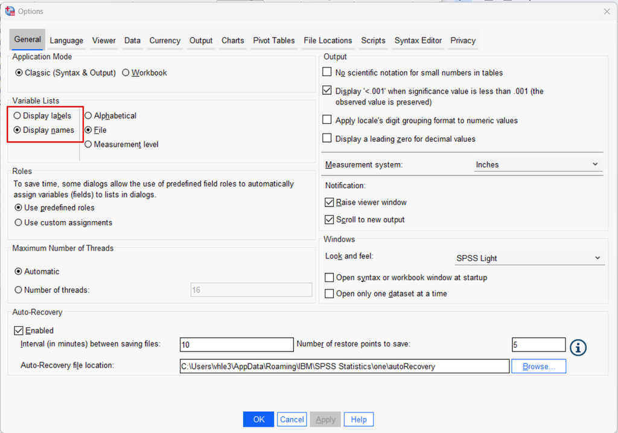

Edit > Options, General tab.

**NoteIn SPSS: check the missing count**

1. Click **Analyze > Descriptive Statistics > Frequencies**.
2. Move **Evaluation** into the **Variable(s)** box on the right.
3. Click **OK**.

[figure not shown]

Evaluation in the Frequencies dialog.

The number of missing values shows under **N > Missing** in the first table. Here it’s 57, and the frequency table lists 99 under Missing, not under Valid.

[figure not shown]

Frequencies output for Evaluation after coding 99 as missing.

**WarningGotcha: Missing says 0**

If **N > Missing** is 0, the coding didn’t work: SPSS is still counting 99 as a score. Go back to the Missing cell and check what you typed.

> When thinking about your own data’s variables, how will missing values be coded?

## 3.2 Coding values for categorical variables

If you import a survey without defined Values for its categorical variables, you may need to enter the value labels yourself. Evaluation has no labels yet: its Values cell says None.

**NoteIn SPSS: label Evaluation’s values**

1. Look up Evaluation’s values and labels in the codebook (codebook ↑).
2. In **Variable View**, click the **Values** cell for **Evaluation**, then the **…** button to the right of the cell.
3. To code a new value, click the **+** button. Evaluation has 5 values, 1 through 5, so click it 5 times.
4. Enter the value and label for each: 1 is *poor*, 2 is *slightly underperformed*, 3 is *met expectations*, 4 is *slightly exceeded expectations* and 5 is *excellent*.
5. Click **OK**. The Values cell now shows the labels you entered.

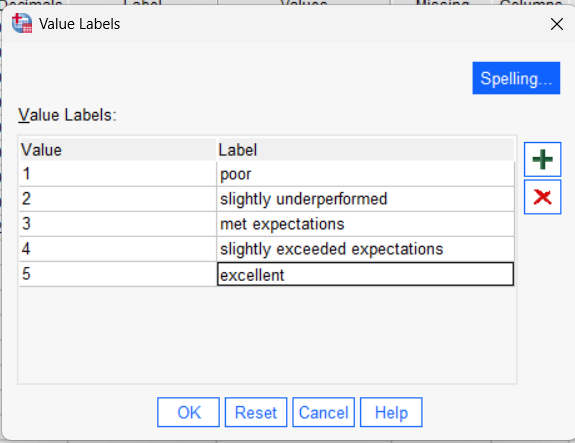

The Value Labels dialog with Evaluation’s five labels.

Now Variable View is informative and ready for further analysis.

[figure not shown]

Variable View after the changes: Evaluation has value labels, 99 as its missing code, and an Ordinal measure.

# 4 Descriptive statistics

## 4.1 Frequency of a categorical variable

**Question: How are employees’ performance evaluations spread across the five ratings?**

**NoteIn SPSS: a frequency table and bar chart**

1. Click **Analyze > Descriptive Statistics > Frequencies**.
2. Select one or more nominal or ordinal variables, such as **Evaluation** (codebook ↑).
3. Click **Statistics**, select the options you want to see, and click **Continue**.
   - For a nominal variable like Gender, select **Mode** only.
   - For an ordinal variable like Evaluation, you can select **Mode**, plus **Quartiles** and **Range**.
4. To make a graph as well as a table, click **Charts**, select **Bar charts**, and click **Continue**.
5. Click **OK**.

[figure not shown]

Statistics for an ordinal variable: Quartiles, Mode and Range.

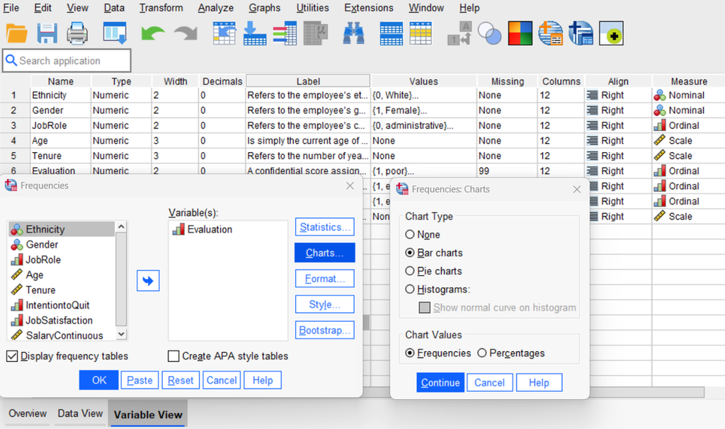

Charts: Bar charts, showing frequencies.

SPSS makes a frequency table for each variable you selected, with the statistics you chose, and a bar chart of how often each category occurs.

By default, SPSS uses your variable’s Label as the chart’s title and horizontal axis title. For Evaluation, that’s a whole sentence.

**NoteIn SPSS: retitle the chart**

1. In the Output Viewer, double-click the chart to open the **Chart Editor**.
2. Double-click the horizontal axis title and change it to **Evaluation**.
3. Double-click the chart title and change it to **Frequency of Evaluation**.
4. Close the Chart Editor.

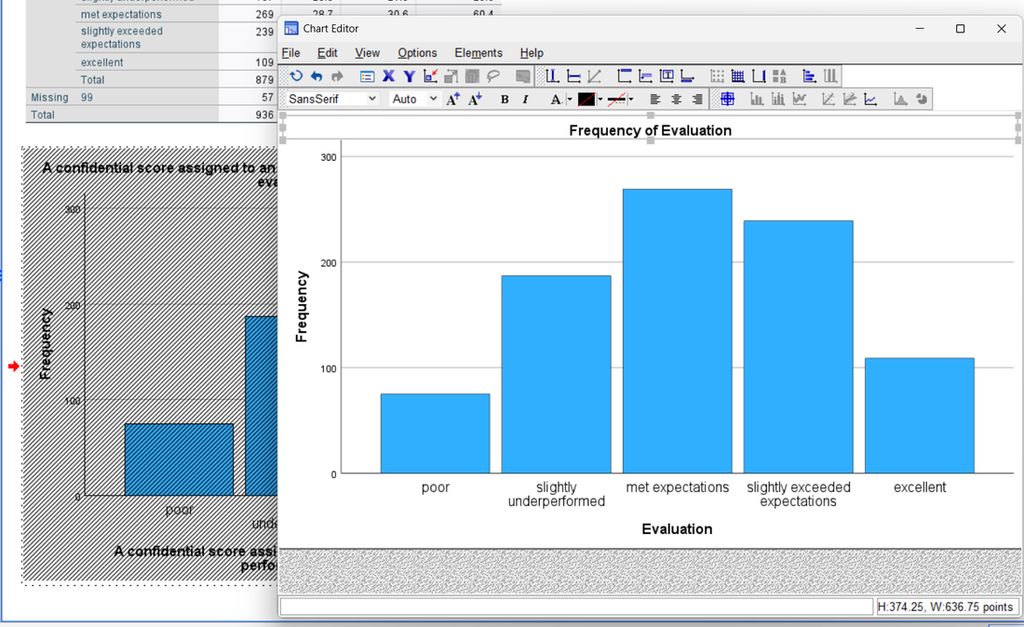

The Chart Editor, with the new titles.

Because Evaluation has many missing values, use the **Valid Percent** column, not Percent, to see each category’s share. Percent divides by all 936 employees, including the 57 with no evaluation; Valid Percent divides by the 879 who have one.

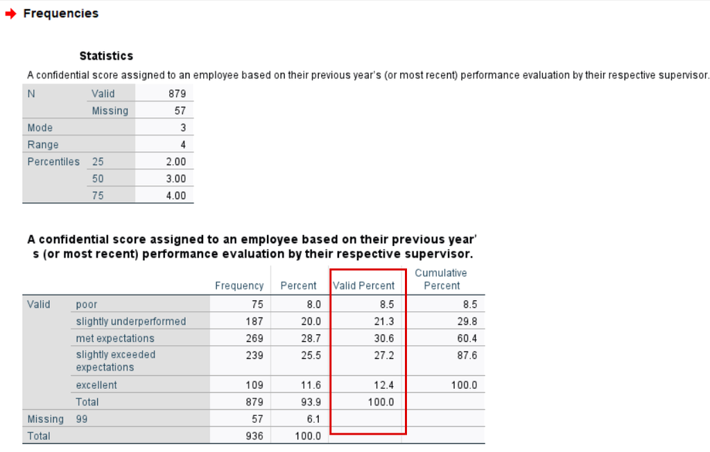

Valid Percent leaves out the missing values.

**Interpretation:** Of the 879 employees with an evaluation, the most common rating is 3, *met expectations* (30.6%). 12.4% were rated *excellent* and 8.5% *poor*, and half of the ratings fall between 2 and 4 (the 25th and 75th percentiles). We use Valid Percent because 57 employees have no evaluation.

## 4.2 Frequency of a scale variable

**Question: How long have employees typically worked at ABC Insurance?**

**NoteIn SPSS: summary statistics and a histogram**

1. Click **Analyze > Descriptive Statistics > Frequencies**. Click **Reset** if Evaluation is still selected.
2. Select one or more scale variables, such as **Tenure** (codebook ↑).
3. Click **Statistics** and select the options you want under Percentile Values, Central Tendency, Distribution and Dispersion. Here we choose **Mean**, **Median** and **Mode** under Central Tendency, and **Std. deviation** and **Range** under Dispersion.
4. Click **Continue**.
5. To make a graph as well as a table, click **Charts**, select **Histograms**, check **Show normal curve on histogram**, and click **Continue**.
6. Uncheck **Display frequency tables**. A frequency table isn’t helpful for a scale variable.
7. Click **OK**.
8. Rename the axis title and chart title as needed.

[figure not shown]

Statistics for a scale variable.

[figure not shown]

Charts: a histogram with a normal curve.

You get a table of statistics and a histogram with a normal curve.

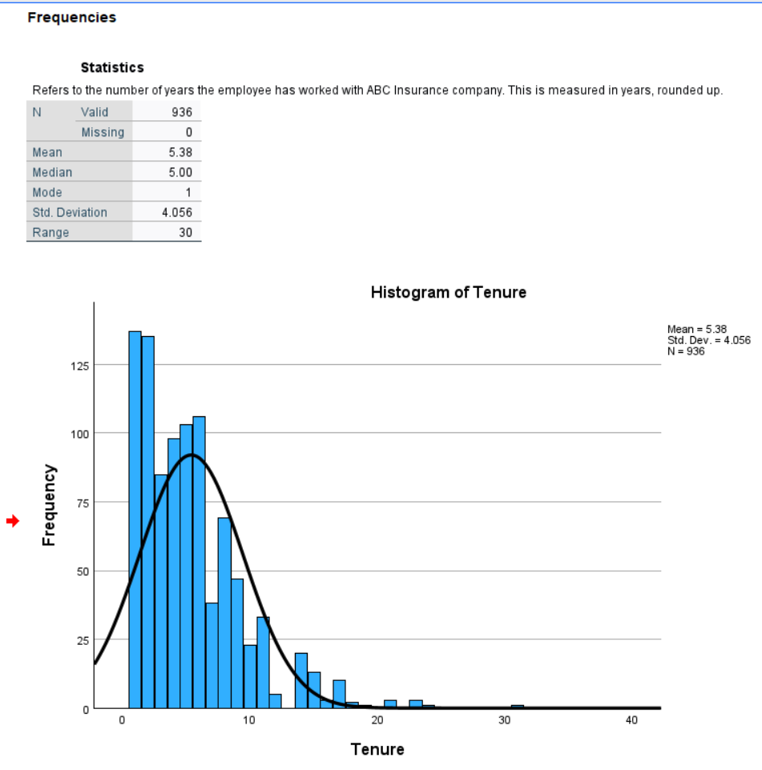

Tenure: statistics and histogram.

**Interpretation:** Employees have worked at ABC Insurance for 5.38 years on average (SD 4.06), with a median of 5 years, and the most common tenure is 1 year. The histogram is right-skewed: most employees have under 10 years, and a few have more than 20. That’s why the mean sits above the median and the normal curve fits the bars poorly.

## 4.3 Two categorical variables together

**Question: Is job role associated with gender?**

**Cross-tabulations**, also known as crosstabs, show how often responses to two categorical variables (nominal or ordinal) occur together. Each crosstab has a row variable and a column variable: each row is a level of the row variable, and each column a level of the column variable. To determine whether the two variables are associated, we can run a **chi-square test**.

**NoteIn SPSS: a crosstab with a chi-square test**

1. Click **Analyze > Descriptive Statistics > Crosstabs**.
2. Move one categorical variable into **Row(s)** (**JobRole** (codebook ↑)) and one into **Column(s)** (**Gender** (codebook ↑)).
3. Click **Statistics**, select **Chi-square**, then click **Continue** and **OK**.

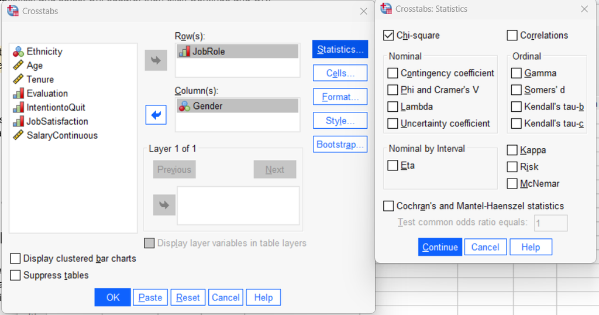

JobRole by Gender, with Chi-square selected.

The output is a crosstab and a chi-square test of independence between the two variables.

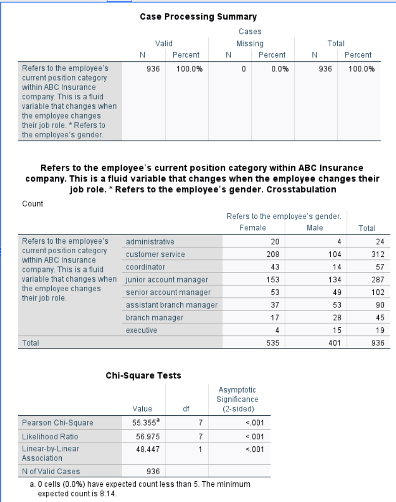

The crosstab and the Chi-Square Tests table.

Look at the first row of the Chi-Square Tests table, Pearson Chi-Square. If its Asymptotic Significance is below 0.05, there is evidence that the two variables are associated.

**Interpretation:** Yes, job role and gender are associated (χ²(7) = 55.355, p < .001). The test says the two are related; the crosstab shows how. Women are most of the administrative (20 of 24) and customer service (208 of 312) staff, and men are most of the branch managers (28 of 45) and executives (15 of 19).

# 5 Inferential statistics

You can run any test in SPSS and receive output, but a variable **should** first be checked for a normal distribution before you run an inferential test that assumes one. A normal distribution forms a symmetrical, bell-shaped curve where most values cluster around a central average and taper off equally on both sides. Normality testing applies to continuous variables only. In this section we assume the data are normal; Checking normality in the Appendix shows how to test it with Explore, and what its result means for the ANOVA and the regression here.

## 5.1 Correlation tables

**Question: Do employees who have been at the company longer earn more?**

A correlation table shows the strength and direction of the relationships between pairs of variables. The Pearson correlation requires two or more continuous variables.

The correlation coefficient (*r*) can be positive or negative, and ranges from −1 to 1:

- 0 means there is no relationship between the two variables.
- −1 means there is a perfect negative relationship.
- 1 means there is a perfect positive relationship.
- A positive coefficient means that as one variable increases, so does the other.
- A negative coefficient means that as one variable increases, the other decreases.

**NoteIn SPSS: a Pearson correlation**

1. Click **Analyze > Correlate > Bivariate**.
2. Move **Tenure** (codebook ↑) and **SalaryContinuous** (codebook ↑) into the **Variables** box.
3. Check **Pearson** under Correlation Coefficients.
4. Check **Flag significant correlations** to mark important results.
5. Click **OK** to run the test.

[figure not shown]

Bivariate Correlations with Tenure and SalaryContinuous.

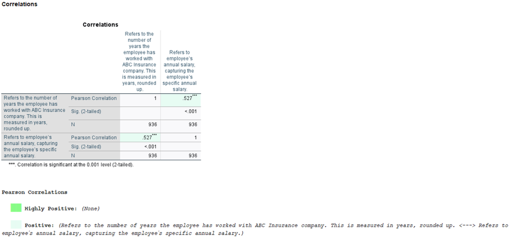

The correlation table.

Asterisks next to a coefficient flag it as significant, and the footnote under the table says at what level: here, three asterisks (***) mean p < 0.001.

**Interpretation:** Yes. Tenure and salary have a moderate positive correlation (r = .527, p < .001, N = 936): employees with longer tenure tend to earn more. A correlation doesn’t show that tenure *causes* higher pay.

## 5.2 Comparing means

The Independent-Samples T Test, One-Sample T Test and One-Way ANOVA compare means and determine whether an observed difference is statistically significant.

- A **One-Sample T Test** compares a sample mean with a known value.
- An **Independent-Samples T Test** compares the means of two independent groups.
- A **One-Way ANOVA** compares the means of three or more groups.

### 5.2.1 One-way ANOVA

**Question: Does average salary differ across job roles?**

ANOVA stands for ANalysis Of VAriance. A one-way ANOVA compares the means of two or more independent groups to determine whether there is statistical evidence that the associated population means are significantly different. You need two variables for this test:

- A **dependent variable** that is continuous (interval or ratio level).
- An **independent variable** that is categorical (two or more groups).

The null and alternative hypotheses of a one-way ANOVA are:

$$H_0: \mu_1 = \mu_2 = \mu_3 = \cdots = \mu_k$$

All $k$ population means are equal.

$$H_1: \text{at least one } \mu_i \text{ is different}$$

At least one of the $k$ population means is not equal to the others.

where $\mu_i$ is the population mean of the $i^{th}$ group, $i = 1, \dots, k$.

In the sample dataset, **SalaryContinuous** is an employee’s annual salary (codebook ↑), and **JobRole** is the employee’s current position within ABC Insurance (codebook ↑). Let’s use ANOVA to test whether salary differs significantly by job role. SalaryContinuous is the dependent variable and JobRole is the independent variable.

**NoteIn SPSS: a one-way ANOVA**

1. Click **Analyze > Compare Means and Proportions > One-Way ANOVA**.
2. Move your continuous dependent variable (**SalaryContinuous**) into the **Dependent List** box.
3. Move your categorical independent variable with three or more groups (**JobRole**) into the **Factor** box.
4. Click **OK**.

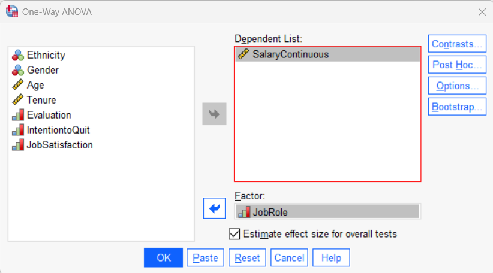

SalaryContinuous by JobRole.

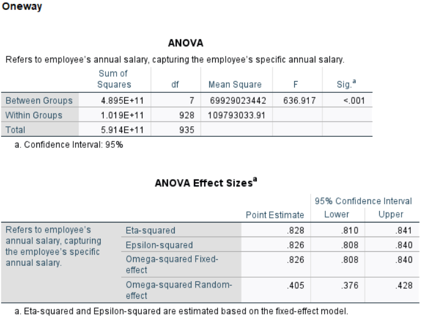

The ANOVA table and effect sizes.

**Interpretation:** Yes. Mean salary differs significantly across job roles ($F_{7,928} = 636.917,\ p < 0.001$): at least one job role’s mean salary is different from the others. The effect is large: eta-squared is .828, so job role accounts for about 83% of the variation in salary. The ANOVA alone doesn’t tell us *which* job roles differ. To find out, follow up with multiple comparison (post hoc) tests, from the **Post Hoc** button in the One-Way ANOVA dialog.

## 5.3 Simple linear regression

**Question: Does tenure predict salary, and by how much?**

Linear regression models the relationship between one independent (“explanatory”) variable and a dependent (“response”) variable by analyzing many observations. The model can then be used to predict and inform future behavior with a degree of statistical confidence. The equation for a simple linear regression (SLR) is:

$$y = \beta_0 + \beta_1 x + \epsilon$$

where:

- $y$: the dependent variable
- $x$: the independent variable
- $\beta_0$: the intercept, the expected value of $y$ when $x = 0$
- $\beta_1$: the slope, how much $y$ is expected to change for every 1-unit increase in $x$
- $\epsilon$: the error term

In simple terms, if you plot a number of data points on a graph to see whether they form a straight line, the SLR is the line of best fit for those points.

For example, we want to model and test whether Tenure (codebook ↑) predicts Salary (codebook ↑). The dependent variable is SalaryContinuous and the independent variable is Tenure, so our model is:

$$\text{SalaryContinuous} = \beta_0 + \beta_1 \, \text{Tenure} + \epsilon$$

**NoteIn SPSS: a simple linear regression**

1. Go to **Analyze > Regression > Linear**.
2. Move **SalaryContinuous** into the **Dependent** box, and **Tenure** into the **Independent(s)** box.
3. Click **OK**.

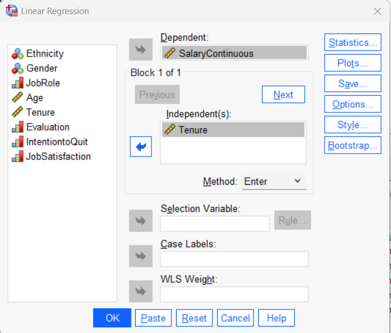

SalaryContinuous as the dependent variable, Tenure as the independent.

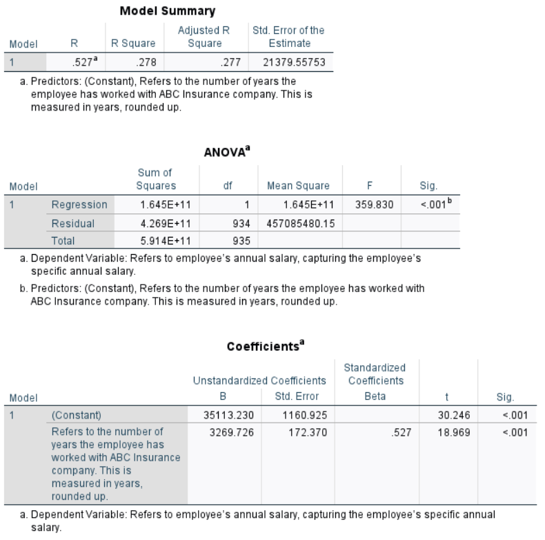

The Model Summary, ANOVA and Coefficients tables.

Where to look in the output:

- **Adjusted R Square** (Model Summary): the share of the variation in the dependent variable that the model explains.
- **B** (Coefficients, Unstandardized): the intercept, in the *(Constant)* row, and the slope, in the Tenure row.
- **Sig.** in the Tenure row: whether tenure is a significant predictor.

**Interpretation:** Yes. Tenure is a statistically significant predictor of salary (t = 18.969, p < .001). The fitted model is predicted salary = $35,113.23 + $3,269.73 × tenure: each additional year of tenure at ABC Insurance adds about $3,270 to an employee’s predicted salary, on average. Tenure explains 27.7% of the variation in salary (adjusted R² = .277), so most of the variation comes from other things, such as job role. R (.527) is the same as the correlation in Section 5.1.

# 6 Exporting output

Once you’ve run the analyses you’re interested in, you can export them to a document file.

**NoteIn SPSS: export your results**

1. To export only one or a few output items, select them in the Output Viewer so they’re highlighted. To export all the output since you opened SPSS, skip to the next step.
2. In the Output Viewer, right-click and select **Export**, or go to **File > Export**.
3. At the top of the Export Output window, **All** exports every analysis you ran in this session; **Selected** exports only the items you highlighted.
4. The **Type** dropdown under Document sets the document format. The default is Word (.docx); you can also choose PDF and other formats.
5. To export graphics instead, choose **None (Graphics only)** as the Document type, then pick a format under **Graphics**.
6. Click **Browse** to choose the folder to save to, then click **OK**.

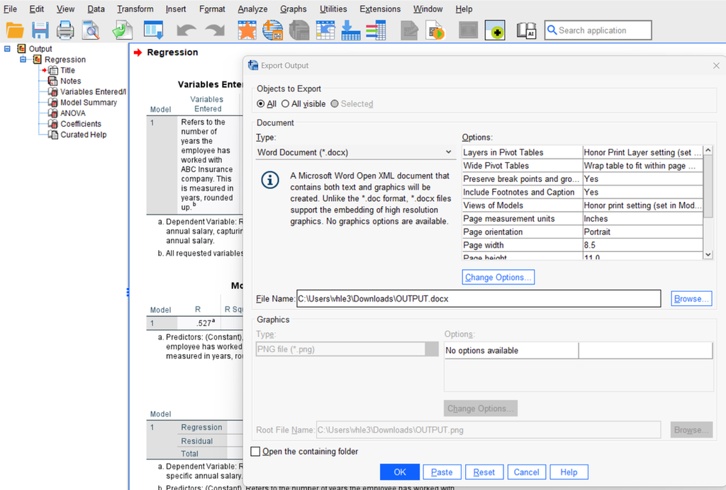

The Export Output window, exporting all output as a Word document.

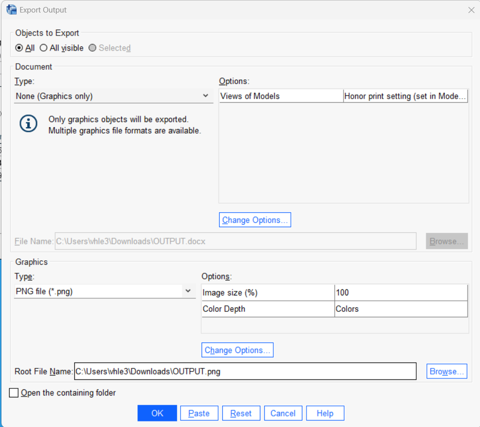

Exporting graphics only, as PNG files.

**WarningGotcha: save to Google Drive, not just the VCL**

If you save your output on the VCL, move it into Google Drive (or other cloud storage) before you leave, so you can get to it from outside the VCL.

## 6.1 Save your files and leave the VCL

**NoteIn the VCL: save to the cloud and leave**

1. In the VCL’s web browser, go to drive.google.com, sign in with your NC State account, and upload your output files and any data you changed.
2. To leave the VCL, close the browser window (or tab) on your own computer that the VCL is running in.

# 7 SPSS resources

- **Get NC State in-person access and live help with SPSS:** go.ncsu.edu/getdatahelp
  - The Data Experience Lab on the 3rd floor of Hill Library has computers with SPSS installed (instead of using the VCL).
  - Consultations with an expert on how to use SPSS for your specific project.
- **Official IBM tutorial:** ibm.com/docs/en/spss-statistics/25.0.0?topic=tutorial. A thorough walkthrough of SPSS.
- **Help with specific techniques:** how2stats (how2statsbook.com).
  - Short [YouTube videos](https://www.youtube.com/user/how2stats/about) focused on explaining specific tasks.
- **Video training on LinkedIn Learning:** [SPSS Statistics Essential Training](https://www.linkedin.com/learning/spss-statistics-essential-training-2/navigating-spss?autoplay=true&resume=false&u=53565897).
  - NC State students have access to LinkedIn Learning, which is also useful for learning other topics, with thousands of videos on software, business and more.
- **Online book-style tutorial:** [UCLA OARC SPSS modules](https://stats.oarc.ucla.edu/spss/modules/).
  - Focuses more on syntax (code) than on the point-and-click interface. SPSS syntax opens up custom analyses and data processing.
- **Asynchronous library guide tutorial:** [Kent State University Libraries, SPSS Tutorials](https://libguides.library.kent.edu/SPSS/home).
  - A sample walkthrough with a provided dataset. It also covers multiple response sets (for “select all that apply” questions) and recoding missing values.

## References

**The data.** Arseneault, R. (2023). *Learn to use descriptive statistics in SPSS to interrogate large employee HR data sets with simulated company data*. In *Sage Research Methods: Business*. SAGE Publications Ltd. https://doi.org/10.4135/9781529629477. NC State students and staff: [open it through NC State Libraries](https://methods-sagepub-com.prox.lib.ncsu.edu/dataset/descriptive-stats-hr-data-spss).

Kent State University Libraries. (2017, May 15). *SPSS Tutorials*. Retrieved September 24, 2026, from https://libguides.library.kent.edu/SPSS

# Appendix

## Checking normality

**Question: Is salary normally distributed?**

You *can* run any test in SPSS and receive output, but a variable should first be checked for a normal distribution before you run an inferential test that assumes one. Normality testing applies to continuous variables only.

**NoteIn SPSS: test for normality with Explore**

1. Click **Analyze > Descriptive Statistics > Explore**.
2. Move a scale variable, such as **SalaryContinuous** (codebook ↑), to the **Dependent List**. Click the **Plots** button.
3. In the Plots dialog, check **Normality plots with tests**. This adds the Shapiro-Wilk and Kolmogorov-Smirnov tests and Q-Q plots.
4. Click **Continue** to return to the main dialog.
5. Click **OK**.

[figure not shown]

Explore, with Normality plots with tests checked.

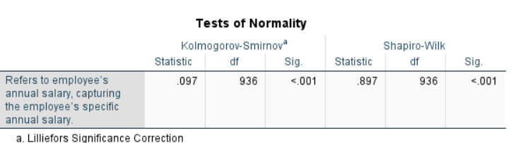

The Tests of Normality table.

Check the **Sig.** value in the Shapiro-Wilk columns of the Tests of Normality table. If it is greater than 0.05, there’s no evidence that the data depart from a normal distribution. If it is below 0.05, the data significantly deviate from a normal distribution.

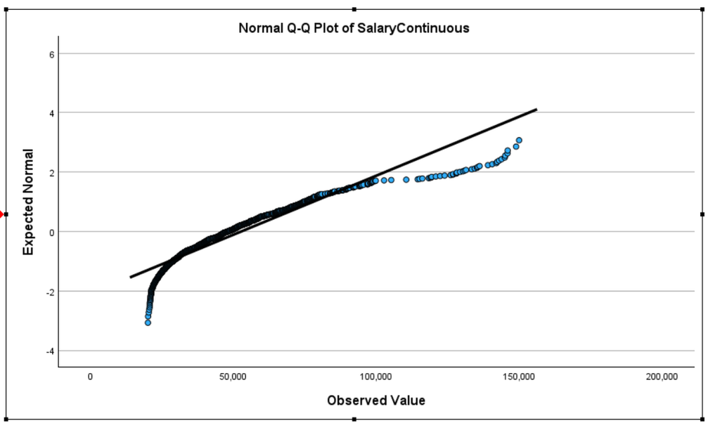

The normal Q-Q plot for SalaryContinuous. If the data were normal, the points would follow the line.

**Interpretation:** No. Salary is not normally distributed: the Shapiro-Wilk test is significant (W = .897, df = 936, p < .001), and in the Q-Q plot the points bend away from the line at both ends.

**WarningGotcha: the ANOVA and the regression use salary anyway**

Salary is the dependent variable in the one-way ANOVA and the regression, and it isn’t normal. Strictly, those tests assume the *residuals* (each employee’s distance from their group mean, or from the regression line) are roughly normal, not the variable as a whole. A skewed variable usually means skewed residuals, though.

With 936 employees this matters less: with large samples, ANOVA and regression results hold up well when the data aren’t normal. With a small sample, or very skewed data, consider an alternative, such as the Kruskal-Wallis test in place of a one-way ANOVA (under **Analyze > Nonparametric Tests**), or transforming the variable (for example, taking its log) before a regression.